# NFL Team Passing Analysis (2001-2023)

## Introduction

This dataset contains NFL passing statistics from 2001-2023 and has records of every single NFL player who has attempted a pass within that time period. Recorded data includes: passing yards, passing touchdowns, pass attempts, completions, interceptions as well as touchdown/interception/completion percentages. More advanced metrics are also included such as sack percentage, passing yards per attempt and more. Source: Kaggle, NFL Passing Statistics (2001-2023).

```python
import seaborn as sns
import pandas as pd
import matplotlib.pyplot as plt
import altair as alt
```

```python
nfl = pd.read_csv("passing_cleaned.csv")
print("Top 5 rows:")
display(nfl.head())
```

```
Top 5 rows:
```

|  | Unnamed: 0 | Player | Tm | Age | G | GS | Cmp | Att | Cmp% | Yds | ... | AY/A | Y/C | Y/G | Rate | Sk | Yds-s | Sk% | NY/A | ANY/A | Year |
| --- | --- | --- | --- | --- | --- | --- | --- | --- | --- | --- | --- | --- | --- | --- | --- | --- | --- | --- | --- | --- | --- |
| 0 | 0 | Kurt Warner | STL | 30 | 16 | 16 | 375 | 546 | 68.7 | 4830 | ... | 8.4 | 12.9 | 301.9 | 101.4 | 38 | 233 | 6.5 | 7.87 | 7.41 | 2001 |
| 1 | 1 | Peyton Manning | IND | 25 | 16 | 16 | 343 | 547 | 62.7 | 4131 | ... | 6.6 | 12.0 | 258.2 | 84.1 | 29 | 232 | 5.0 | 6.77 | 5.88 | 2001 |
| 2 | 2 | Brett Favre | GNB | 32 | 16 | 16 | 314 | 510 | 61.6 | 3921 | ... | 7.6 | 12.5 | 245.1 | 94.1 | 22 | 151 | 4.1 | 7.09 | 7.02 | 2001 |
| 3 | 3 | Aaron Brooks | NOR | 25 | 16 | 16 | 312 | 558 | 55.9 | 3832 | ... | 6.0 | 12.3 | 239.5 | 76.4 | 50 | 330 | 8.2 | 5.76 | 4.99 | 2001 |
| 4 | 4 | Rich Gannon | OAK | 36 | 16 | 16 | 361 | 549 | 65.8 | 3828 | ... | 7.2 | 10.6 | 239.3 | 95.5 | 27 | 155 | 4.7 | 6.38 | 6.61 | 2001 |

5 rows × 27 columns

More in depth, detailed information about the dataset below.

```python
print("\nDataframe Info:")
print(nfl.info())

print("\nDescriptive Statistics:")
print(nfl.describe())
```

```
Dataframe Info:
<class 'pandas.core.frame.DataFrame'>
RangeIndex: 2350 entries, 0 to 2349
Data columns (total 27 columns):
 #   Column      Non-Null Count  Dtype
---  ------      --------------  -----
 0   Unnamed: 0  2350 non-null   int64
 1   Player      2350 non-null   object
 2   Tm          2350 non-null   object
 3   Age         2350 non-null   int64
 4   G           2350 non-null   int64
 5   GS          2350 non-null   int64
 6   Cmp         2350 non-null   int64
 7   Att         2350 non-null   int64
 8   Cmp%        2350 non-null   float64
 9   Yds         2350 non-null   int64
 10  TD          2350 non-null   int64
 11  TD%         2350 non-null   float64
 12  Int         2350 non-null   int64
 13  Int%        2350 non-null   float64
 14  1D          2350 non-null   int64
 15  Lng         2350 non-null   int64
 16  Y/A         2350 non-null   float64
 17  AY/A        2350 non-null   float64
 18  Y/C         2350 non-null   float64
 19  Y/G         2350 non-null   float64
 20  Rate        2350 non-null   float64
 21  Sk          2350 non-null   int64
 22  Yds-s       2350 non-null   int64
 23  Sk%         2350 non-null   float64
 24  NY/A        2350 non-null   float64
 25  ANY/A       2350 non-null   float64
 26  Year        2350 non-null   int64
dtypes: float64(11), int64(14), object(2)
memory usage: 495.8+ KB
None

Descriptive Statistics:
        Unnamed: 0          Age            G           GS          Cmp  \
count  2350.000000  2350.000000  2350.000000  2350.000000  2350.000000
```

[output cut: 24 more lines]

```
50%       6.100000    10.900000    92.550000    80.050000     4.000000
75%       7.675000    12.200000   206.250000    95.800000    23.000000
max     101.000000    81.000000   371.200000   158.300000    76.000000

             Yds-s          Sk%         NY/A        ANY/A         Year
count  2350.000000  2350.000000  2350.000000  2350.000000  2350.000000
mean     76.754468     5.616128     6.469494     5.848681  2011.913191
std      95.830273     7.312900     7.513787    12.611336     6.795382
min       0.000000     0.000000   -11.000000   -45.000000  2001.000000
25%       0.000000     0.000000     3.800000     2.415000  2006.000000
50%      26.000000     5.000000     5.630000     5.130000  2012.000000
75%     145.000000     7.700000     6.820000     6.857500  2018.000000
max     477.000000    80.000000    81.000000   101.000000  2023.000000

[8 rows x 25 columns]
```

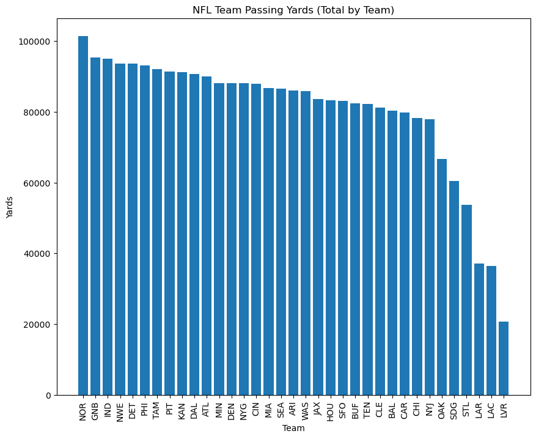

```python
team_totals = nfl.groupby("Tm", as_index=False)["Yds"].sum()

team_totals = team_totals.query("Tm != '2TM' and Tm != '3TM'").sort_values("Yds", ascending=False)

# plot
plt.figure(figsize=(10, 8))
plt.bar(team_totals["Tm"], team_totals["Yds"])
plt.title("NFL Team Passing Yards (Total by Team)")
plt.xlabel("Team")
plt.ylabel("Yards")
plt.xticks(rotation=90)
plt.show()
```

First, I analyzed passing yards by team to give a quick look of which franchises have produced the most passing yards across the entire timeframe of the dataset. Pass-heavy teams rank among some of the top, while more run-based teams tend to rank lower. The New Orleans Saints have had over 100,000 passing yards in the past two decades which shows how pass heavy they were with quarterbacks such as Drew Brees. The Las Vegas Raiders, have had the lowest passing yardage with just over 20,000. But, this does not take into account that the Las Vegas Raiders are a newer franchise as they were established in 2017. This dataset contains both data from the Las Vegas Raiders and the previously known Oakland Raiders prior to 2017. Other examples of this include the St. Louis Rams and San Diego Chargers moving to Los Angeles.

```python
import altair as alt

nfl_filtered = nfl[~nfl["Tm"].isin(["2TM","3TM"])]

alt.Chart(nfl_filtered).mark_circle(size=100).encode(
    x=alt.X('Yds:Q',
            title='Passing Yards',
            axis=alt.Axis(ticks=True, tickCount=10)),
    y=alt.Y('TD:Q', title='Touchdowns'),
    color='Tm:N',
    tooltip=['Player','Tm','Yds','TD']
).properties(
    width=800,
    height=600
).interactive()
```

[interactive chart not shown]

Moving on to this scatterplot, it contains record of every single player who has attempted a pass in the NFL in the past two decades. The graph compares their passing yards to the number of touchdowns scored. Peyton Manning stands out in this as he had one of the best seasons with 5,477 passing yards and 55 touchdowns scored with the Denver Broncos. The scatterplot reveals some standout players alongside Manning with Drew Brees, Patrick Mahomes, Aaron Rodgers and Tom Brady rounding out the top five. The bottom of the plot is very interesting as it contains many non-quarterbacks who have thrown passing touchdowns. Some might be very surprising, one being star running-back Derrick Henry having 2 passing touchdowns with 14 passing yards. These players are unusual and mainly come from trick plays or very specific instances where wide recievers, running-backs and tight ends can end up with a passing opportunity in which they throw it into the endzone.

```python
team_int = nfl[~nfl["Tm"].isin(["2TM","3TM"])].groupby("Tm", as_index=False)["Int"].sum()

alt.Chart(team_int.sort_values("Int", ascending=False)).mark_bar().encode(
    x=alt.X('Tm:N', sort='-y', title='Team'),
    y=alt.Y('Int:Q', title='Total Interceptions'),
    color='Tm:N',
    tooltip=['Tm','Int']
).properties(
    width=900,
    height=500
).interactive()
```

[interactive chart not shown]

This graph shows the total number of interceptions that have been thrown by every single NFL team over the years. Summing up these interception totals can help give insights into which franchises have struggled with turnovers historically. The Cleveland Browns standout with a total of 419 interceptions thrown in the past two decades while the Las Vegas Raiders have the lowest with 77 (bear in mind Las Vegas Raiders hav existed since 2017).

```python
td_int_scatter = alt.Chart(nfl).mark_circle(size=80, opacity=0.6).encode(
    x=alt.X("Int%:Q", title="Interception %"),
    y=alt.Y("TD%:Q", title="Touchdown %"),
    color=alt.Color("Tm:N", legend=None),
    tooltip=["Player","Tm","Year","TD%","Int%"]
).properties(
    title="Risk vs Reward: TD% vs INT%",
    width=700,
    height=500
).interactive()

td_int_scatter
```

[interactive chart not shown]

Another way of showing player efficiency is touchdown percentage and interception percentage. These will show players who have the best touchdown/interception ratio. Though, when analyzing the results, you begin to see that mainly non-quarterbacks have the highest touchdown/interception ratios. An example of this is is LaDainian Tomlinson who was the former running back of the San Diego Chargers before they moved to Los Angeles. He has a 75% touchdown rate with 0 interceptions. These could be considered outliers as these are players who get very few passing attempts which come very rarely during special trick plays. These non-quarterbacks have a very small sample size as they could have one or two plays which could result in a passing touchdown from a trick play. Some other players like this include Las Vegas Raiders wide reciever, Jakobi Meyers and former Cleveland Brown wide reciever, Jarvis Landry. This would be the biggest limitation of this plot if one wants to find the quarterbacks with the best touchdown/interception ratio but closer analysis can reveal those statistics as well.

```python
yearly_cmp = nfl.groupby("Year", as_index=False)["Cmp%"].mean()

cmp_trend = alt.Chart(yearly_cmp).mark_line(point=True).encode(
    x=alt.X("Year:O", title="Year"),
    y=alt.Y("Cmp%:Q", title="Average Completion %"),
    tooltip=["Year","Cmp%"]
).properties(
    title="League-wide Completion % Over Time",
    width=700,
    height=500
).interactive()

cmp_trend
```

[interactive chart not shown]

As offenses have improved in the past two decades, so has the NFL passing game. The line chart above shows the increase of completion percentages over the past two decades. The 54.7% average passing completion in 2001 rose 7% to an average of 61.7% passing completion in 2023 which displays how the league has become more efficient in passing schemes.

```python
rate_box = alt.Chart(nfl[~nfl["Tm"].isin(["2TM","3TM"])]).mark_boxplot(extent="min-max").encode(
    x=alt.X("Tm:N", sort="y", title="Team"),
    y=alt.Y("Rate:Q", title="Passer Rating"),
    color=alt.Color("Tm:N", legend=None),
    tooltip=["Tm","Rate"]
).properties(
    title="Distribution of Passer Rating by Team",
    width=900,
    height=500
).interactive()

rate_box
```

[interactive chart not shown]

Lastly, I analyzed passer rating distributions across every NFL team. These come in the form of boxplots which can show which organizations have consistently produced the most efficient passers in the league as well as those who have the lowest passer ratings. From this it can be concluded that teams such as the Green Bay Packers, New Orleans Saints, New England Packers and the Kansas City Chiefs rank among some of the best passers in the past two decades. This is most likely due to having some of the most prominent quarterbacks in history with Aaron Rodgers, Tom Brady, Patrick Mahomes, and Drew Brees being the leaders of those passing offenses. In contrast, teams such as the Buffalo Bills and Cleveland Browns have some of the lowest rated passer ratings. The Bills, having many quarterbacks who struggled before the arrival of Josh Allen and the Browns having a very unstable quarterback room over the last two decades. Teams like the Carolina Panthers and the Tennessee Titans have a spread-out distribution in the time frame due to change from having decent quarterback play to very inefficient quarterback over the years.

## Conclusion

These six charts display the development of modern NFL passing offenses. Some franshises have shown to have consistent success in the passing game while others fluctuate or are dissapointing. The analysis revealed interesting metrics in players who have had the best balance between yardage and touchdowns as well as the variability between the large amount of players recorded in the dataset. It has also shown how much the game of football has developed in the past two decades in terms of passing as the efficiency and accuracy of passers has improved, reflecting the changing strategies of the league.